# Multivariate Data Analysis Assignment #6

2018170865 산업경영공학부 박재현

2021. 6. 6.

```r
    library(dplyr)
```

## [Step 1] 데이터 변환

mooc_dataset <- read.csv(“big_student_clear_third_version.csv”).  
위 스크립트를 사용하여 원 데이터를 불러오면 총 416,921건의 관측치와 22개의 변수가 존재하는 데이터 프레임이 생성된다. 이 중에서 아래 그림과 같이 userid_DI (사용자 아이디)를 Transaction ID로 하고, institute (강좌 제공 기관), course_id (강좌코드), final_cc_cname_DI (접속 국가), LoE_DI (학위 과정)을 하나의 string으로 결합하여 Item Name으로 하는 Single 형식의 csv 파일로 저장하고자 한다.

### [Q1] 아래 사항을 수행하는 스크립트와 최종 csv 파일 내용을 캡처하여 제시하시오.

- 1단계: 제공된 csv파일을 읽어온 뒤 Item Name에 해당하는 네 개의 변수를 각각 Institute, Course, Region, Degree로 정의한 변수명에 저장하시오.
- 2단계: Region에 해당하는 변수의 경우 한 칸 공백(“ “)을 제거하는 전처리를 수행하시오(hint: gsub( ) 함수 사용).
- 3단계: 네 변수를 밑줄(_)로 연결하여 RawTransactions로 정의된 하나의 변수에 저장하시오(hint: paste( ) 함수 사용).
- 4단계: Transaction ID에 해당하는 변수와 3단계의 결과물을 한 칸 공백(“ “)으로 연결하여 MOOC_transactions로 정의된 변수에 저장하시오.
- 5단계: 4단계의 MOOC_transactions 변수를 MOOC_User_Course.csv라는 파일명으로 저장하고 저장된 파일을 열어 내용을 확인하시오.

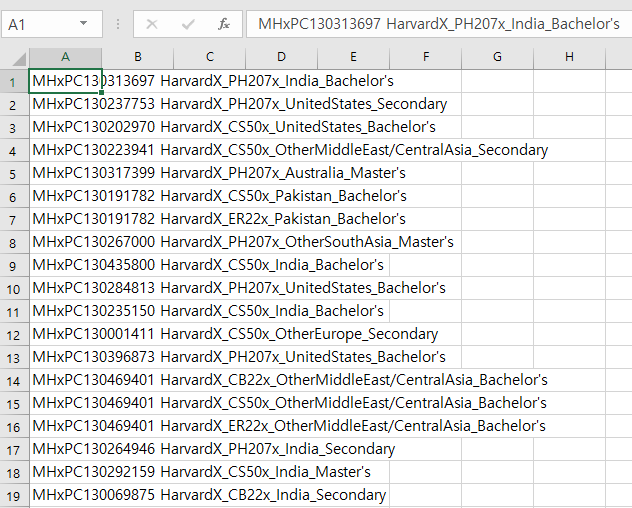

```r
# 1단계
mooc_data <- read.csv("big_student_clear_third_version.csv")

Institute <- mooc_data$institute
Course <- mooc_data$course_id
Region <- mooc_data$final_cc_cname_DI
Degree <- mooc_data$LoE_DI

# 2단계
Region <- gsub(" ", "", Region)

# 3단계
RawTransactions <- paste(Institute, Course, Region, Degree , sep = "_" )

# 4단계
MOOC_transactions <- paste(mooc_data$userid_DI, RawTransactions, sep=" ")

# 5단계
write.table(MOOC_transactions, "MOOC_User_Course.csv", row.names = FALSE, col.names = FALSE)
```

## [Step 2] 데이터 불러오기 및 기초 통계량 확인

### [Q2-1] [Q1]에서 생성된 single format의 데이터를 read.transactions( )함수를 이용하여 읽어들이고 summary( )함수를 사용하여 해당 데이터의 속성을 파악해보시오.

```r
rm(list = ls())
data_single <- read.transactions("MOOC_User_Course.csv",
                                format = "single", col = c(1,2),
                                rm.duplicates=TRUE)

inspect(data_single[1:10])
```

```
     items                                     transactionID
[1]  {MITx_14.73x_UnitedKingdom_Secondary}    MHxPC130000002
[2]  {HarvardX_CS50x_India_Secondary,
      HarvardX_ER22x_India_Secondary}         MHxPC130000004
[3]  {HarvardX_ER22x_UnitedStates_Bachelor's} MHxPC130000006
[4]  {HarvardX_CB22x_UnitedStates_Master's}   MHxPC130000007
[5]  {MITx_6.00x_UnitedKingdom_Bachelor's}    MHxPC130000008
[6]  {HarvardX_CS50x_Egypt_Secondary,
      MITx_6.00x_Egypt_Secondary}             MHxPC130000011
[7]  {MITx_8.02x_UnitedStates_Bachelor's}     MHxPC130000014
[8]  {HarvardX_CB22x_Unknown/Other_Secondary} MHxPC130000016
[9]  {MITx_8.02x_Brazil_Bachelor's}           MHxPC130000018
[10] {HarvardX_CB22x_UnitedStates_Doctorate}  MHxPC130000021
```

```r
summary(data_single)
```

```
transactions as itemMatrix in sparse format with
 333946 rows (elements/itemsets/transactions) and
 4092 columns (items) and a density of 0.00030072

most frequent items:
    MITx_6.00x_UnitedStates_Bachelor's      MITx_6.00x_UnitedStates_Secondary
                                 14092                                   8774
           MITx_6.00x_India_Bachelor's           MITx_6.002x_India_Bachelor's
                                  7774                                   7596
HarvardX_CS50x_UnitedStates_Bachelor's                                (Other)
                                  7356                                 365344

element (itemset/transaction) length distribution:
sizes
     1      2      3      4      5      6      7      8      9     10     11
277491  42477   9872   2777    795    289    107     45     36     23     19
    12     13
     9      6

   Min. 1st Qu.  Median    Mean 3rd Qu.    Max.
  1.000   1.000   1.000   1.231   1.000  13.000

includes extended item information - examples:
```

|  | labels |
| --- | --- |
| 1 | HarvardX_CB22x_Australia_Bachelor's |
| 2 | HarvardX_CB22x_Australia_Master's |
| 3 | HarvardX_CB22x_Australia_Secondary |

```
includes extended transaction information - examples:
```

|  | transactionID |
| --- | --- |
| 1 | MHxPC130000002 |
| 2 | MHxPC130000004 |
| 3 | MHxPC130000006 |

### [Q2-2] 아이템 이름과 아이템 카운트를 이용 하여 워드클라우드를 생성해 보시오. 워드클라우드 생성 시 Color는 실습 자료로 제시된 것과 다른 색상을 사용하여 생성하며, min.freq는 최소 100 이상의 값을 직접 지정해서 생성하시오.

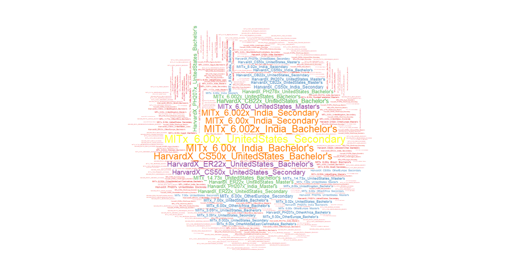

```r
itemName <- itemLabels(data_single)
itemCount <- itemFrequency(data_single)*nrow(data_single)

palete <- brewer.pal(9, "Set1")
wordcloud(words = itemName, freq = itemCount, min.freq = 150, scale = c(4, 0.2), col = palete, random.order = FALSE)
```

### [Q2-3] itemFrequencyPlot( )함수를 사용하여 최소 빈도 1% 이상 등장한 Items들의 Bar Chart를 도시하시오. 상위 5개의 Item에 대해 접속 국가는 각각 어느 국가인지 확인하시오.

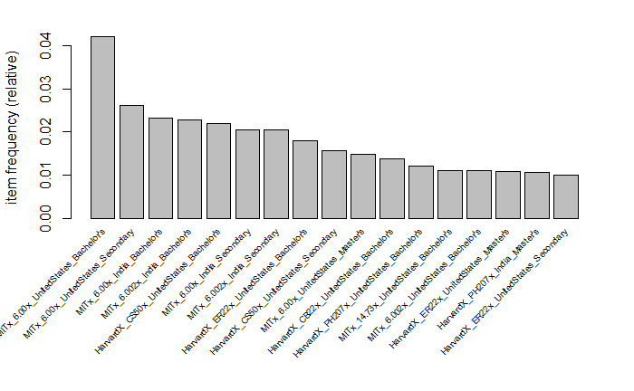

## [Step 3] 규칙 생성 및 결과 해석

### [Q3-1] 최소 10개 이상의 규칙이 생성될 수 있도록 support와 confidence의 값을 조정해 가면서 각 support-confidence 조합에 대해 총 몇 가지의 규칙이 생성되는지 확인하고 그 결과를 아래 표와 같은 형태로 제시하시오. 최소한 3개 이상의 support, 3개 이상의 confidence, 총 9개 이상의 조합에 대한 규칙 생성을 수행하시오.

| Nuber of rules | confidence=0.1 | confidence=0.2 | confidence=0.4 |  |
| --- | --- | --- | --- | --- |
| support=0.0001 | 1442 | 892 | 472 |  |
| support=0.0002 | 497 | 228 | 77 |  |
| support=0.0003 | 255 | 102 | 36 |  |

```r
ls_rules
```

```
[1] 1442  892  472  497  228   77  255  102   36
```

### [Q3-2] support = 0.001, confidence = 0.05로 지정하여 생성된 연관규칙 분석들에 대해 다음 질문에 대한 답과 본인의 생각을 서술하시오.

```
The parameter interactive is deprecated. Use engine='interactive' instead.
```

```
Interactive mode.
Select a region with two clicks!
```

[output not shown]

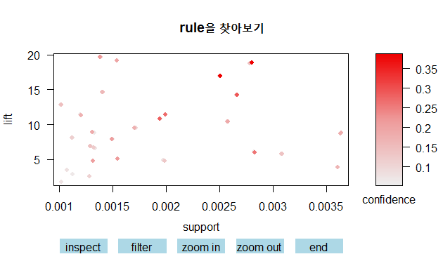

```r
rules <- apriori(data_single,
                 control = list(verbose = F),
                 parameter=list(minlen = 2, support=0.001, confidence=0.05))

plot(rules, measure=c("support", "lift"),
     shading="confidence",
     control=list(main = "rule을 찾아보기"),
     interactive = TRUE)
```

- Support가 가장 높은 규칙은 무엇인가?
1. {MITx_6.00x_India_Secondary} => {MITx_6.002x_India_Secondary}
2. {MITx_6.002x_India_Secondary} => {MITx_6.00x_India_Secondary}
3. {HarvardX_CS50x_UnitedStates_Bachelor’s} => {MITx_6.00x_UnitedStates_Bachelor’s}
4. {MITx_6.00x_UnitedStates_Bachelor’s} => {HarvardX_CS50x_UnitedStates_Bachelor’s} 총 4개의 규칙이 support = 0.0036으로 가장 높은 규칙이다.

```r
quality(rules) <- round(quality(rules), digits = 4)

rules.sorted1 <- sort(rules, by = "support")
inspect(rules.sorted1[1:5])
```

```
    lhs                                         rhs                                      support confidence coverage   lift count
[1] {MITx_6.00x_India_Secondary}             => {MITx_6.002x_India_Secondary}             0.0036     0.1780   0.0204 8.7170  1215
[2] {MITx_6.002x_India_Secondary}            => {MITx_6.00x_India_Secondary}              0.0036     0.1782   0.0204 8.7170  1215
[3] {HarvardX_CS50x_UnitedStates_Bachelor's} => {MITx_6.00x_UnitedStates_Bachelor's}      0.0036     0.1637   0.0220 3.8787  1204
[4] {MITx_6.00x_UnitedStates_Bachelor's}     => {HarvardX_CS50x_UnitedStates_Bachelor's}  0.0036     0.0854   0.0422 3.8787  1204
[5] {MITx_6.002x_India_Bachelor's}           => {MITx_6.00x_India_Bachelor's}             0.0031     0.1356   0.0227 5.8248  1030
```

- Confidence가 가장 높은 규칙은 무엇인가?
1. {MITx_8.02x_India_Bachelor’s} => {MITx_6.002x_India_Bachelor’s} 이 규칙이 confidence = 0.3860으로 가장 높은 규칙이다.

```r
rules.sorted2 <- sort(rules, by = "confidence")
inspect(rules.sorted2[1:5])
```

```
    lhs                                     rhs                                 support confidence coverage    lift count
[1] {MITx_8.02x_India_Bachelor's}        => {MITx_6.002x_India_Bachelor's}       0.0025     0.3860   0.0065 16.9683   836
[2] {MITx_8.02x_India_Secondary}         => {MITx_6.002x_India_Secondary}        0.0028     0.3854   0.0072 18.8735   932
[3] {HarvardX_CS50x_India_Secondary}     => {MITx_6.00x_India_Secondary}         0.0027     0.2910   0.0091 14.2365   888
[4] {MITx_6.002x_UnitedStates_Secondary} => {MITx_6.00x_UnitedStates_Secondary}  0.0019     0.2824   0.0069 10.7466   648
[5] {HarvardX_CS50x_India_Bachelor's}    => {MITx_6.00x_India_Bachelor's}        0.0020     0.2671   0.0075 11.4735   668
```

- Lift가 가장 높은 규칙은 무엇인가?
1. {MITx_8.02x_UnitedStates_Bachelor’s} => {MITx_6.002x_UnitedStates_Bachelor’s}
2. {MITx_6.002x_UnitedStates_Bachelor’s} => {MITx_8.02x_UnitedStates_Bachelor’s}

이 2가지 규칙이 lift = 19.6151로 가장 높은 규칙이다.

```r
rules.sorted3 <- sort(rules, by = "lift")
inspect(rules.sorted3[1:5])
```

```
    lhs                                        rhs                                     support confidence coverage    lift count
[1] {MITx_8.02x_UnitedStates_Bachelor's}    => {MITx_6.002x_UnitedStates_Bachelor's}    0.0014     0.2167   0.0064 19.6151   465
[2] {MITx_6.002x_UnitedStates_Bachelor's}   => {MITx_8.02x_UnitedStates_Bachelor's}     0.0014     0.1261   0.0110 19.6151   465
[3] {HarvardX_CB22x_UnitedStates_Secondary} => {HarvardX_ER22x_UnitedStates_Secondary}  0.0015     0.1920   0.0080 19.1144   512
[4] {HarvardX_ER22x_UnitedStates_Secondary} => {HarvardX_CB22x_UnitedStates_Secondary}  0.0015     0.1527   0.0100 19.1144   512
[5] {MITx_8.02x_India_Secondary}            => {MITx_6.002x_India_Secondary}            0.0028     0.3854   0.0072 18.8735   932
```

- 만일 하나의 규칙에 대한 효용성 지표를 Support × Confidence × Lift로 정의한다면 효용성이 가장 높은 규칙 1위~3위는 어떤 것들인가?
1. {MITx_8.02x_India_Secondary} => {MITx_6.002x_India_Secondary} : 0.020366771
2. {MITx_8.02x_India_Bachelor’s} => {MITx_6.002x_India_Bachelor’s} : 0.016374409
3. {HarvardX_CS50x_India_Secondary} => {MITx_6.00x_India_Secondary} : 0.011185618

|  | lhs | rhs | eval |
| --- | --- | --- | --- |
| 1 | {MITx_8.02x_India_Secondary} | {MITx_6.002x_India_Secondary} | 0.020366771 |
| 2 | {MITx_8.02x_India_Bachelor's} | {MITx_6.002x_India_Bachelor's} | 0.016374409 |
| 3 | {HarvardX_CS50x_India_Secondary} | {MITx_6.00x_India_Secondary} | 0.011185618 |
| 4 | {MITx_6.002x_India_Secondary} | {MITx_8.02x_India_Secondary} | 0.007224021 |
| 5 | {HarvardX_CS50x_India_Bachelor's} | {MITx_6.00x_India_Bachelor's} | 0.006129144 |

- 생성된 규칙을 plot( )함수의 “graph” method를 이용하여 도시할 경우 두 아이템이 서로 조건절/결과절을 달리해서 생성되는 경우가 존재함을 확인할 수 있다(X -> Y 규칙과 Y -> X 규칙이 함께 존재한다는 뜻). 이 중에서 세 가지 규칙을 선택하여 각 규칙들에 대한 Support/Confidence/Lift 값을 확인해보고 조건절과 결과절의 위치에 따라서 어떤 지표 값들이 차이가 나는지와 왜 그러한 상황이 발생하는지 서술하시오.

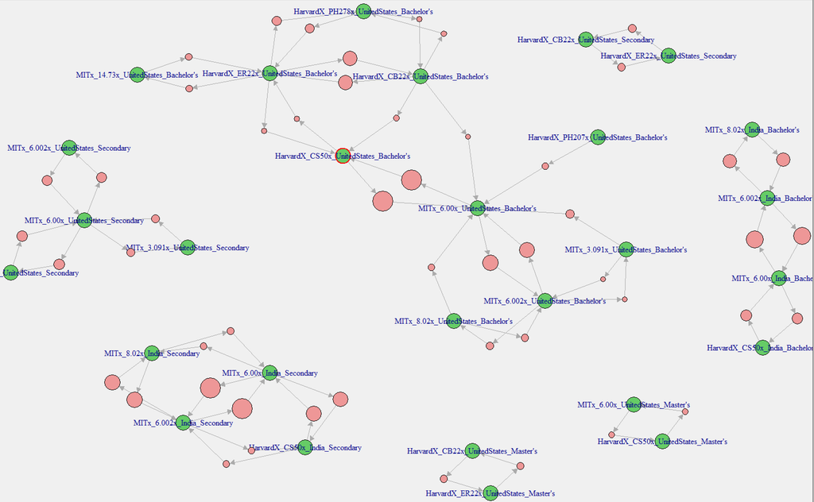

```r
plot(rules, method = "graph",
     control = list(type = "items", col=brewer.pal(11,"Spectral")),
     interactive = TRUE ,shading = NA)
```

1. MIT, 6.002, 미국, Secondary <-> MIT, 6.00, 미국, Secondary

|  | support | confidence | lift |
| --- | --- | --- | --- |
| X -> Y | 0.0019 | 0.2824 | 10.7466 |
| Y -> X | 0.0019 | 0.0739 | 10.7466 |

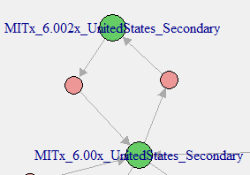

```r
inspect(subset(rules, lhs %in% c("MITx_6.002x_UnitedStates_Secondary")))
inspect(subset(rules, rhs %in% c("MITx_6.002x_UnitedStates_Secondary")))
```

[output not shown]

2. Harvard, CB22, 미국, Master’s <-> Harvard, ER22, 미국, Master’s

|  | support | confidence | lift |
| --- | --- | --- | --- |
| X -> Y | 0.0014 | 0.1578 | 14.5932 |
| Y -> X | 0.0014 | 0.1307 | 14.5932 |

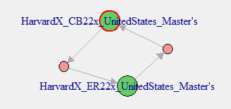

```r
inspect(subset(rules, lhs %in% c("HarvardX_CB22x_UnitedStates_Master's")))
```

```
    lhs                                       rhs                                        support confidence    coverage     lift count
[1] {HarvardX_CB22x_UnitedStates_Master's} => {HarvardX_ER22x_UnitedStates_Master's} 0.001413402   0.157754 0.008959532 14.59316   472
```

```r
inspect(subset(rules, rhs %in% c("HarvardX_CB22x_UnitedStates_Master's")))
```

```
    lhs                                       rhs                                        support confidence   coverage     lift count
[1] {HarvardX_ER22x_UnitedStates_Master's} => {HarvardX_CB22x_UnitedStates_Master's} 0.001413402  0.1307479 0.01081013 14.59316   472
```

3. MIT, 6.00, 미국, Master’s <-> Harvard, CS50, 미국, Master’s

|  | support | confidence | lift |
| --- | --- | --- | --- |
| X -> Y | 0.0012 | 0.0811 | 11.3812 |
| Y -> X | 0.0012 | 0.1688 | 11.3812 |

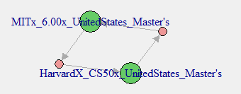

```r
inspect(subset(rules, lhs %in% c("MITx_6.00x_UnitedStates_Master's")))
```

```
    lhs                                   rhs                                        support confidence   coverage     lift count
[1] {MITx_6.00x_UnitedStates_Master's} => {HarvardX_CS50x_UnitedStates_Master's} 0.001203787 0.08114655 0.01483473 11.38117   402
```

```r
inspect(subset(rules, rhs %in% c("MITx_6.00x_UnitedStates_Master's")))
```

```
    lhs                                       rhs                                    support confidence    coverage     lift count
[1] {HarvardX_CS50x_UnitedStates_Master's} => {MITx_6.00x_UnitedStates_Master's} 0.001203787  0.1688366 0.007129895 11.38117   402
```

다음 규칙들에서 조건절과 결과절의 위치에 따라 confidence의 값이 달라지는 것을 확인하였다. 3번의 경우로 설명을 해보자면, MIT, 6.00 수업을 듣고 Harvard, CS50 수업을 듣는 확률이 Harvard, CS50 수업을 듣고 MIT, 6.00 수업을 듣는 확률보다 낮다는 것을 의미한다(0.08 < 0.17). 즉, Confidence 값의 차이는 동일한 두 개의 아이템을 사용했더라도 방향성에 따라서 다른 상황으로 고려되어야 한다는 것을 의미한다. 예를 들면, Harvard 강의에서 MIT 강의를 추천해줬을 수도 있고, Harvard 강의에 부족한 부분이 있어서 추가적으로 MIT 강의를 수강했을 수도 있는 어떤 상황이 존재했을 것이다.

### [Extra Question] 이 외 수업시간에 다루지 않은 연관규칙분석 시각화 및 해석을 시도해 보시오.

1. grouped

조건절과 결과절을 각각 축으로 한 그래프를 보여준다. 원의 크기는 support이고, 색깔을 lift이다. 조건절 앞의 숫자는 연관규칙의 숫자를 나타낸다. 예를 들어, [MIT-6.00-India-Secondary -> MIT-6.002-India-Secondary]의 규칙의 서포트는 가장 크지만, 리프트는 낮다는 것을 알 수있다. 아쉽게도 confidence를 나타내는 지표가 그래프에 없다.

[figure not shown]

2. matrix3D

이 방법은 조건절, 결과절, lift를 차원으로 가지는 그래프를 보여준다. support, confidence의 지표가 없다. 따라서 이 방법은 두 규칙이 독립사건인지 판단하고, lift값이 1보다 얼마나 더 큰지 판단하는데에만 해석이 가능한 그래프이다. 각각의 규칙을 보기보다는 전체적으로 한 눈에 쉽게 파악하기 쉬운 그래프이다. 예를 들어, 전체적으로 lift값이 1보다 크고, 20보다는 작다는 사실을 알 수 있다.

```
method 'matrix3D' is deprecated use method 'matrix' with engine '3d'
```

```
Itemsets in Antecedent (LHS)
 [1] "{HarvardX_CB22x_UnitedStates_Secondary}"
 [2] "{HarvardX_ER22x_UnitedStates_Secondary}"
 [3] "{MITx_8.02x_India_Bachelor's}"
 [4] "{HarvardX_ER22x_UnitedStates_Master's}"
 [5] "{HarvardX_CB22x_UnitedStates_Master's}"
 [6] "{MITx_8.02x_India_Secondary}"
 [7] "{MITx_6.002x_UnitedStates_Bachelor's}"
 [8] "{MITx_8.02x_UnitedStates_Bachelor's}"
 [9] "{MITx_6.002x_India_Secondary}"
[10] "{HarvardX_CS50x_India_Bachelor's}"
[11] "{MITx_6.002x_India_Bachelor's}"
[12] "{HarvardX_CS50x_UnitedStates_Master's}"
[13] "{MITx_6.00x_UnitedStates_Master's}"
[14] "{MITx_6.002x_UnitedStates_Secondary}"
```

[output cut: 42 more lines]

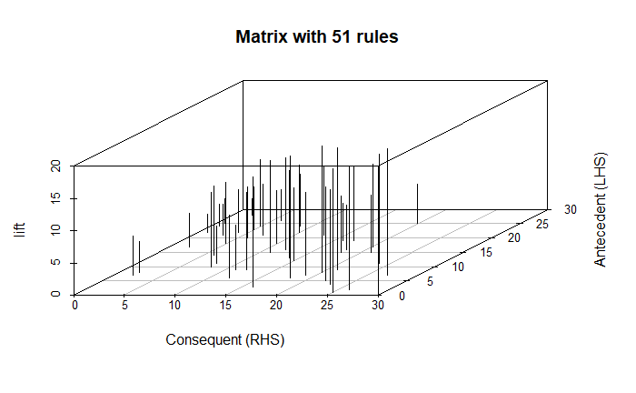

```r
plot(rules, method = "matrix3D")
```